# DSC 680 Project 1

### h1n1 Strain of Flu

```r
reg1 <- lm(h1n1 ~ year, diseases_full)
summary(reg1)
```

```
##
## Call:
## lm(formula = h1n1 ~ year, data = diseases_full)
##
## Residuals:
##    Min     1Q Median     3Q    Max
## -18865  -8555  -4936   -820  97210
##
## Coefficients:
##             Estimate Std. Error t value Pr(>|t|)
## (Intercept) -2350283    2085914  -1.127    0.276
## year            1176       1040   1.131    0.274
##
## Residual standard error: 24830 on 17 degrees of freedom
##   (79 observations deleted due to missingness)
## Multiple R-squared:  0.06996,    Adjusted R-squared:  0.01525
## F-statistic: 1.279 on 1 and 17 DF,  p-value: 0.2738
```

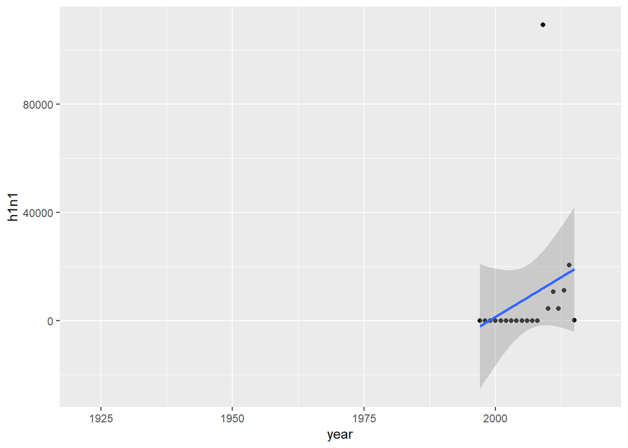

```r
ggplot(diseases_full, aes(x=year, y=h1n1)) + geom_point() + geom_smooth(method='lm')
```

Like with the earlier regressions, let’s zoom in on this one.

```r
reg1 <- lm(h1n1 ~ year, d2000)
summary(reg1)
```

```
##
## Call:
## lm(formula = h1n1 ~ year, data = d2000)
##
## Residuals:
##    Min     1Q Median     3Q    Max
## -19333  -8868  -5754  -2795  97258
##
## Coefficients:
##             Estimate Std. Error t value Pr(>|t|)
## (Intercept) -2523096    2977170  -0.847    0.411
## year            1262       1483   0.851    0.409
##
## Residual standard error: 27350 on 14 degrees of freedom
##   (4 observations deleted due to missingness)
## Multiple R-squared:  0.04917,    Adjusted R-squared:  -0.01875
## F-statistic: 0.724 on 1 and 14 DF,  p-value: 0.4092
```

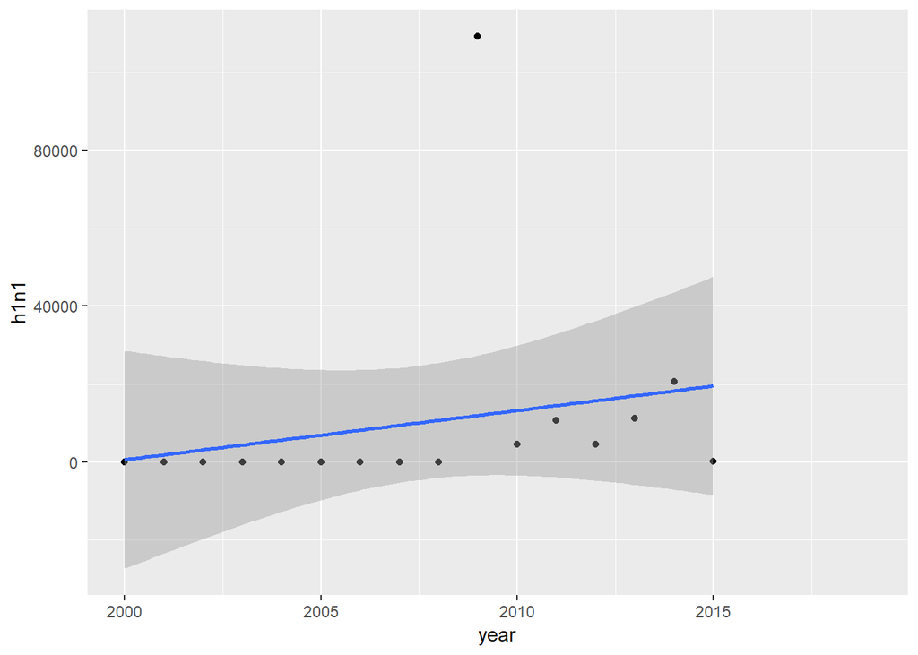

```r
ggplot(d2000, aes(x=year, y=h1n1)) + geom_point() + geom_smooth(method='lm')
```

Interesting. This is another case of the regression line not being statistically significant (p-value = 0.4092). Part of that will be because of the outbreak in 2009.

### h1 Strain of Flu

```r
reg1 <- lm(h1 ~ year, diseases_full)
summary(reg1)
```

```
##
## Call:
## lm(formula = h1 ~ year, data = diseases_full)
##
## Residuals:
##     Min      1Q  Median      3Q     Max
## -1264.5 -1160.2  -863.8   477.9  6803.6
##
## Coefficients:
##              Estimate Std. Error t value Pr(>|t|)
## (Intercept) -44794.15  171694.06  -0.261    0.797
## year            22.86      85.59   0.267    0.793
##
## Residual standard error: 2043 on 17 degrees of freedom
##   (79 observations deleted due to missingness)
## Multiple R-squared:  0.004178,   Adjusted R-squared:  -0.0544
## F-statistic: 0.07132 on 1 and 17 DF,  p-value: 0.7926
```

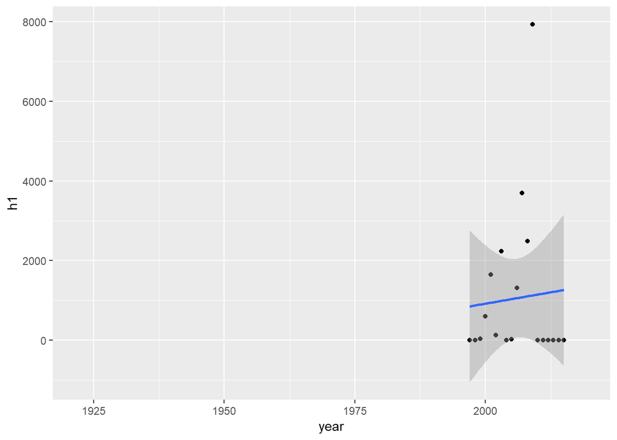

```r
ggplot(diseases_full, aes(x=year, y=h1)) + geom_point() + geom_smooth(method='lm')
```

Let’s also zoom in on this one.

```r
reg1 <- lm(h1 ~ year, d2000)
summary(reg1)
```

```
##
## Call:
## lm(formula = h1 ~ year, data = d2000)
##
## Residuals:
##     Min      1Q  Median      3Q     Max
## -1424.1 -1093.6  -958.8   246.9  6750.4
##
## Coefficients:
##             Estimate Std. Error t value Pr(>|t|)
## (Intercept) 100227.3   237410.7   0.422    0.679
## year           -49.3      118.3  -0.417    0.683
##
## Residual standard error: 2181 on 14 degrees of freedom
##   (4 observations deleted due to missingness)
## Multiple R-squared:  0.01226,    Adjusted R-squared:  -0.05829
## F-statistic: 0.1738 on 1 and 14 DF,  p-value: 0.6831
```

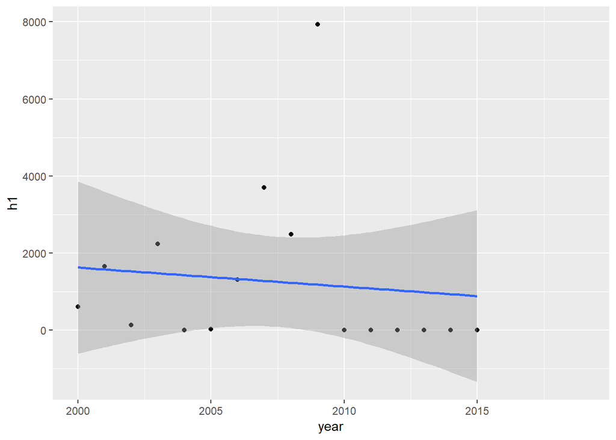

```r
ggplot(d2000, aes(x=year, y=h1)) + geom_point() + geom_smooth(method='lm')
```

Here’s another interesting case where the regression is not statistically significant (p-value = 0.6831). This is due to the outliers in the data. What I find really interesting here, though, is that the number of cases seems to be decreasing year over year for the h1 strain of flu.

### h3 Strain of Flu

```r
reg1 <- lm(h3 ~ year, diseases_full)
summary(reg1)
```

```
##
## Call:
## lm(formula = h3 ~ year, data = diseases_full)
##
## Residuals:
##      Min       1Q   Median       3Q      Max
## -10922.4  -4686.6    716.2   4484.5  10750.9
##
## Coefficients:
##               Estimate Std. Error t value Pr(>|t|)
## (Intercept) -2784223.3   511429.5  -5.444 4.38e-05 ***
## year            1392.4      254.9   5.462 4.22e-05 ***
## ---
## Signif. codes:  0 '***' 0.001 '**' 0.01 '*' 0.05 '.' 0.1 ' ' 1
##
## Residual standard error: 6087 on 17 degrees of freedom
##   (79 observations deleted due to missingness)
## Multiple R-squared:  0.637,  Adjusted R-squared:  0.6156
## F-statistic: 29.83 on 1 and 17 DF,  p-value: 4.221e-05
```

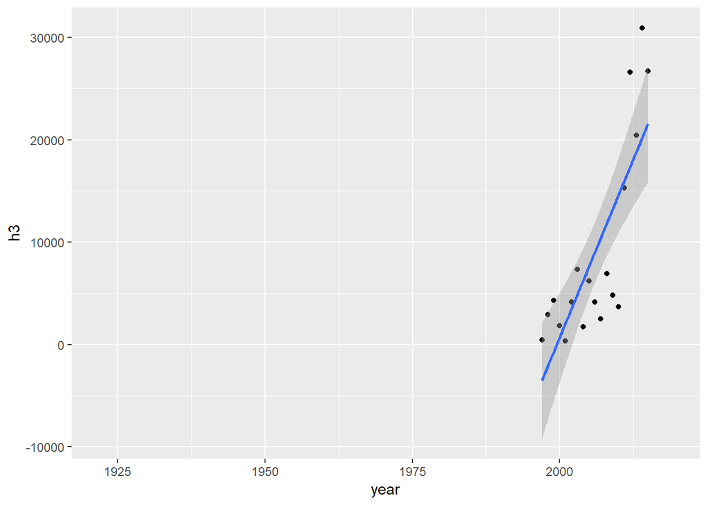

```r
ggplot(diseases_full, aes(x=year, y=h3)) + geom_point() + geom_smooth(method='lm')
```

Let’s also look closer at this.

```r
reg1 <- lm(h3 ~ year, d2000)
summary(reg1)
```

```
##
## Call:
## lm(formula = h3 ~ year, data = d2000)
##
## Residuals:
##      Min       1Q   Median       3Q      Max
## -11017.6  -3606.3    417.5   4042.1   9101.1
##
## Coefficients:
##               Estimate Std. Error t value Pr(>|t|)
## (Intercept) -3565276.1   650551.1  -5.480 8.10e-05 ***
## year            1781.1      324.1   5.496 7.88e-05 ***
## ---
## Signif. codes:  0 '***' 0.001 '**' 0.01 '*' 0.05 '.' 0.1 ' ' 1
##
## Residual standard error: 5975 on 14 degrees of freedom
##   (4 observations deleted due to missingness)
## Multiple R-squared:  0.6833, Adjusted R-squared:  0.6607
## F-statistic: 30.21 on 1 and 14 DF,  p-value: 7.877e-05
```

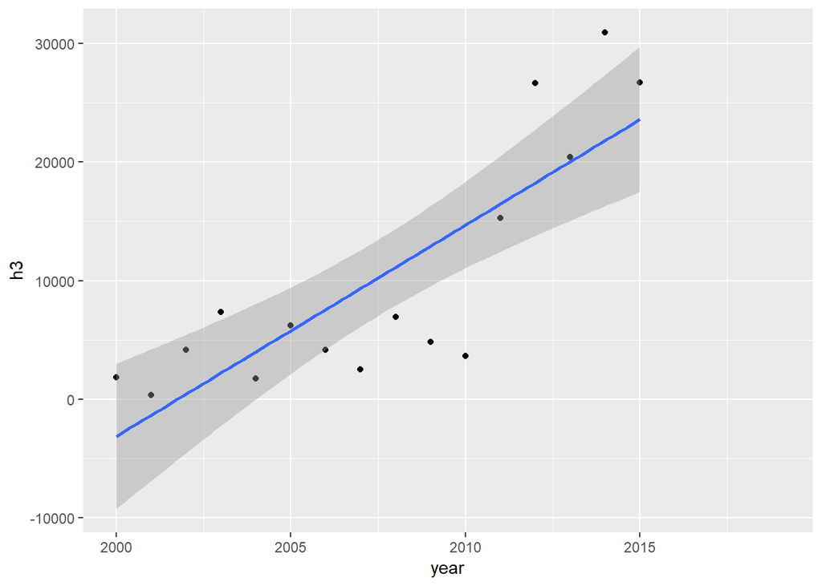

```r
ggplot(d2000, aes(x=year, y=h3)) + geom_point() + geom_smooth(method='lm')
```

Oh, now this is interesting. Where most of the previous regression lines were not statistically significant, this one is (p-value = 7.877e-05). This means that the number of cases of h3 flu have been increasing and are likely to continue increasing year over year. That is worrisome.